# Data_Analysis_ND_p4_nmhw

Nicholas Hunt-Walker

Before we do anything, let’s call the requisite libraries and go to the right working directory.

```r
library(ggplot2)
library(gridExtra)
library(GGally)
setwd("/Users/Nick/Documents/udacity/projects/project4/")
```

And now we load the data. Note that the column descriptions can be found here

```r
prosper <- read.csv("prosperLoanData.csv")
names(prosper)
```

```
##  [1] "ListingKey"
##  [2] "ListingNumber"
##  [3] "ListingCreationDate"
##  [4] "CreditGrade"
##  [5] "Term"
##  [6] "LoanStatus"
##  [7] "ClosedDate"
##  [8] "BorrowerAPR"
##  [9] "BorrowerRate"
## [10] "LenderYield"
## [11] "EstimatedEffectiveYield"
## [12] "EstimatedLoss"
## [13] "EstimatedReturn"
## [14] "ProsperRating..numeric."
## [15] "ProsperRating..Alpha."
```

[output cut: 66 more lines]

There are five columns that contain date information. These are: - ListingCreationDate - ClosedDate - DateCreditPulled - FirstRecordedCreditLine - LoanOriginationDate

These may be useful for later, but as they stand right now they’re not usable. Let’s make them datetime objects.

Write a function that takes in a dataframe and a column of choice, and adds columns to the dataframe that splits the datetime object. I want the year, the month (maybe cyclical?), the day, as well as the date as a decimal of the year.

```r
split_to_columns <- function(df, input_colnum, output_colname_assoc_arr) {
  dates <- strptime(df[, input_colnum], format="%Y-%m-%d %H:%M:%S")
  df[output_colname_assoc_arr["year"]] <- as.numeric(strftime(dates, format="%Y"))
  df[output_colname_assoc_arr["month"]] <- as.numeric(strftime(dates, format="%m"))
  df[output_colname_assoc_arr["day"]] <- as.numeric(strftime(dates, format="%d"))
  df[output_colname_assoc_arr["decimal_date"]] <- df[output_colname_assoc_arr["year"]] + (as.numeric(strftime(dates, format="%j"))/366)

  return(df)
}
```

```r
#column 3
listing_creation_date_set <- c()
listing_creation_date_set["year"] <- "ListingCreationDate_year"
listing_creation_date_set["month"] <- "ListingCreationDate_month"
listing_creation_date_set["day"] <- "ListingCreationDate_day"
listing_creation_date_set["decimal_date"] <- "ListingCreationDate_decimal"

#column 7
closed_date_set <- c()
closed_date_set["year"] <- "ClosedDate_year"
closed_date_set["month"] <- "ClosedDate_month"
closed_date_set["day"] <- "ClosedDate_day"
closed_date_set["decimal_date"] <- "ClosedDate_decimal"

#column 25
credit_pulled_set <- c()
credit_pulled_set["year"] <- "DateCreditPulled_year"
credit_pulled_set["month"] <- "DateCreditPulled_month"
credit_pulled_set["day"] <- "DateCreditPulled_day"
credit_pulled_set["decimal_date"] <- "DateCreditPulled_decimal"

#column 28
first_recorded_credit_set <- c()
first_recorded_credit_set["year"] <- "FirstRecordedCreditLine_year"
first_recorded_credit_set["month"] <- "FirstRecordedCreditLine_month"
first_recorded_credit_set["day"] <- "FirstRecordedCreditLine_day"
first_recorded_credit_set["decimal_date"] <- "FirstRecordedCreditLine_decimal"

#column 65
loan_orig_date_set <- c()
loan_orig_date_set["year"] <- "LoanOriginationDate_year"
loan_orig_date_set["month"] <- "LoanOriginationDate_month"
loan_orig_date_set["day"] <- "LoanOriginationDate_day"
loan_orig_date_set["decimal_date"] <- "LoanOriginationDate_decimal"

prosper <- split_to_columns(prosper, 3, listing_creation_date_set)
prosper <- split_to_columns(prosper, 7, closed_date_set)
prosper <- split_to_columns(prosper, 25, credit_pulled_set)
prosper <- split_to_columns(prosper, 28, first_recorded_credit_set)
prosper <- split_to_columns(prosper, 65, loan_orig_date_set)
```

First Plots: Histograms of potentially interesting things

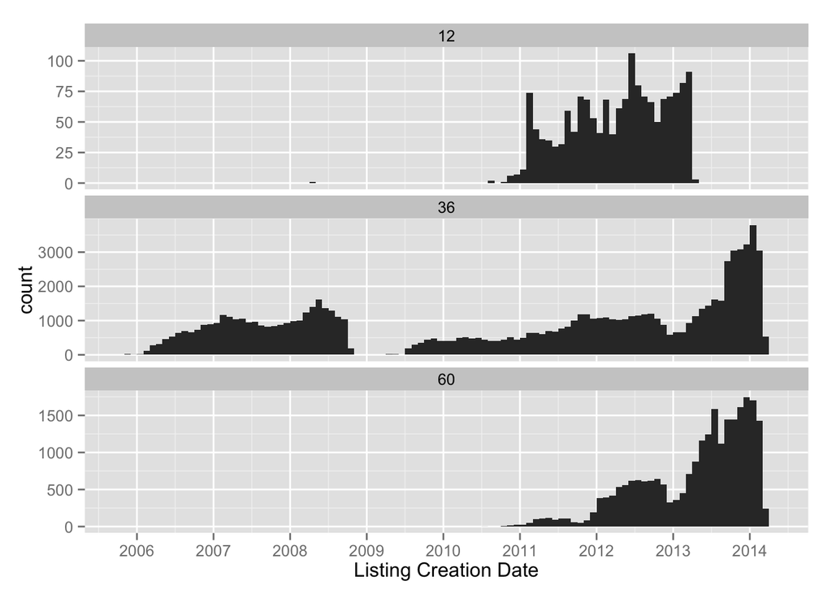

```r
#Listing Creation Date split by term length
ggplot(data=subset(prosper, !is.na(Term)), aes(x=ListingCreationDate_decimal)) +
  geom_histogram(binwidth=1/12) +
  xlab("Listing Creation Date") +
  scale_x_continuous(breaks=seq(2005, 2015)) +
  facet_wrap(~Term, ncol = 1, scales="free_y")
```

[output not shown]

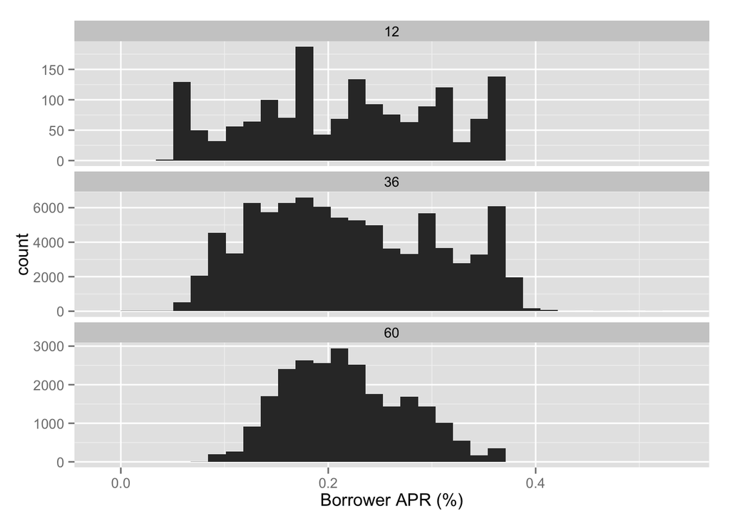

```r
#Borrower APR split by term length
ggplot(data=subset(prosper, !is.na(Term)), aes(x=BorrowerAPR)) +
  geom_histogram() +
  xlab("Borrower APR (%)") +
  facet_wrap(~Term, ncol = 1, scales="free_y")
```

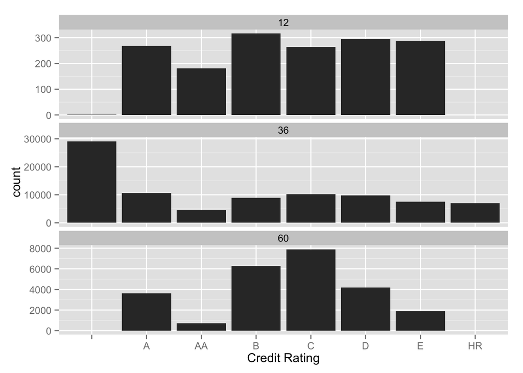

```r
ggplot(data=subset(prosper, !is.na(Term) & !is.na(ProsperRating..Alpha.)), aes(x=ProsperRating..Alpha.)) +
  geom_histogram() +
  xlab("Credit Rating") +
  facet_wrap(~Term, ncol = 1, scales="free_y")
```

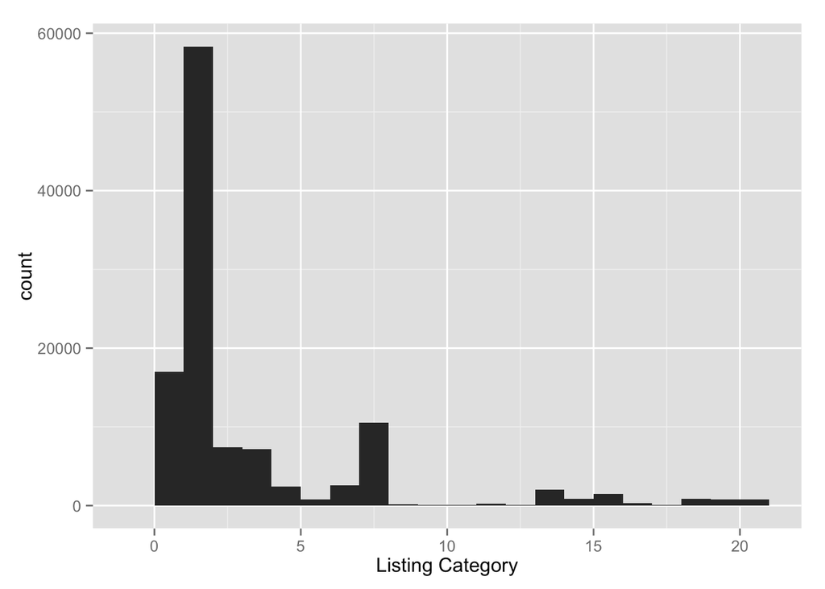

```r
ggplot(data=prosper, aes(x=ListingCategory..numeric.)) +
  geom_histogram(binwidth=1) +
  xlab("Listing Category")
```

Is the stated monthly income a continuous series of numbers or is it split into categories?

```r
summary(prosper$StatedMonthlyIncome)
```

```
##    Min. 1st Qu.  Median    Mean 3rd Qu.    Max.
##       0    3200    4667    5608    6825 1750000
```

Looks to be continuous to me. between 0 and $1.75 million. I should be able to make a histogram of that too. This is the stated monthly income *at the time of borrowing*

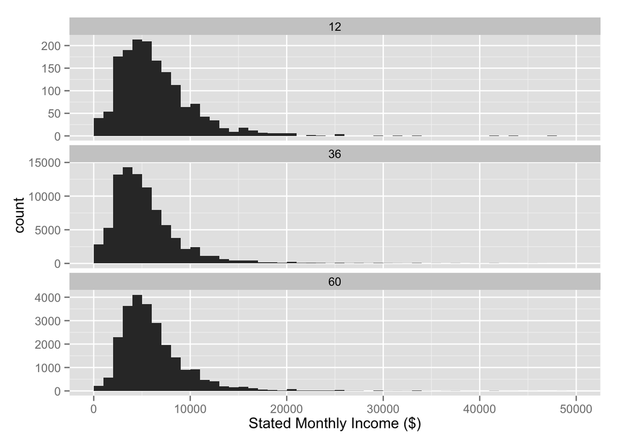

```r
ggplot(data=prosper, aes(x=StatedMonthlyIncome)) +
  geom_histogram(binwidth=1000) +
  xlim(0, 50000) +
  xlab("Stated Monthly Income ($)") +
  facet_wrap(~Term, ncol=1, scales="free_y")
```

What about the original loan amount?

```
## stat_bin: binwidth defaulted to range/30. Use 'binwidth = x' to adjust this.
```

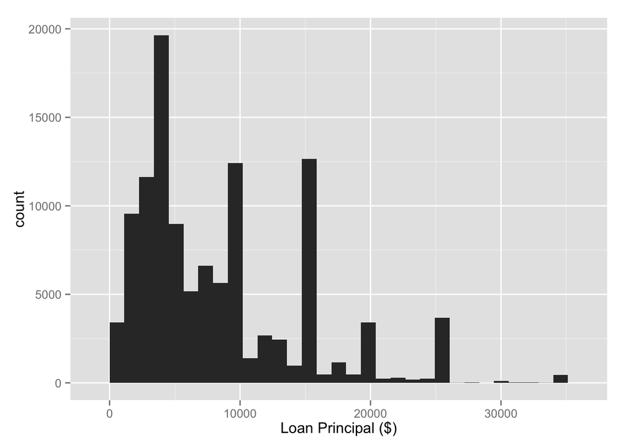

```r
ggplot(data=prosper, aes(x=LoanOriginalAmount)) +
  geom_histogram() +
  xlab("Loan Principal ($)")
```

Hmm…. Is there some correlation between loan amount and stated monthly income?

```r
with(prosper, cor.test(LoanOriginalAmount, StatedMonthlyIncome))
```

```
##
##  Pearson's product-moment correlation
##
## data:  LoanOriginalAmount and StatedMonthlyIncome
## t = 69.353, df = 113940, p-value < 2.2e-16
## alternative hypothesis: true correlation is not equal to 0
## 95 percent confidence interval:
##  0.1956816 0.2068243
## sample estimates:
##       cor
## 0.2012595
```

Correlation coefficient = 0.2012595. Quite lower than what I was expecting. Let’s see what the scatterplot says

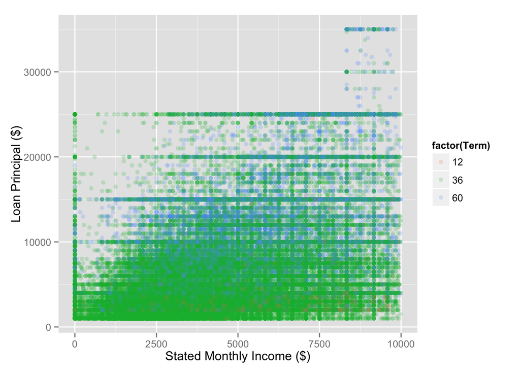

```r
ggplot(data=subset(prosper, StatedMonthlyIncome < 10000), aes(y=LoanOriginalAmount, x=StatedMonthlyIncome)) +
  geom_point(position="jitter", alpha=0.2, aes(color=factor(Term))) +
  xlab("Stated Monthly Income ($)") +
  ylab("Loan Principal ($)")
```